# Using the spIBDerapp

```r
library(spIBDerverse)
```

# Introduction

The SpIBDer-verse is a collection of methods that was primarily developed for the analysis of IBD networks, but can in principle be used for networks of any type (this usability in development). SpIBDer-verse can be used for three main approaches to network analysis: (i) visualisation, (ii) data exploration and (iii) formal hypothesis testing.

The SpIBDer-App is designed to be modular, with modules arranged into tabs, with the exception of three tabs for loading/checking data (*Load data*, *Edge info* and *Node info*) and one tab for exporting figures (*Export plot*). New modules can be added in future releases of the SpIBDer-verse as new methods are developed, or if users request new functionality.

Any new network analysis begin with the same task: getting your data into the app. Networks in general require two types of information: node and edge information.

1. **Node information:** (meta data) reflects properties of the individual units in your analysis: most likely sampled individuals, and may include variables such as their sample ID, genetic sex, age at death, etc. The first column in this file should contain the node (individual) ID, and then each row contains any meta data/information about the nodes that you might want to visualise or analyse.
2. **Edge information:** this file contains information about the connections between node (individuals), and hence the first two column must contain the names of two nodes as found in the node information. This table can include numerical or categorical information, such as the IBD information from ancIBD, the geographic distance between two burials or the type of relationship if it has been estimated (Parent/Child, 4th-degree etc).

This is the minimum information that can be uploaded to the app to run SpIBDer-app. We now explain how each module works, tips and tricks for using the app and how some output can be interpreted.

# Running the app

To launch the SpIBDer-app, first load the package and then run the app by typing into the command line in R:

```r
require(spIBDerverse)
spibder_app()
```

# Loading data

Please note that the “Load distance data” function is currently under development and cannot currently be used.

## Pre-loaded and simulated data

When SpIBDer-App opens, you will (by default) be in the *Load Data* Tab [1], and (again by default) specifically in the *Example dataset* mode [2]. This mode allows users to load one of three simulated data sets, which can be selected in the drop-down list [3], and can be used to explore the functionality of the SpIBDer-App.

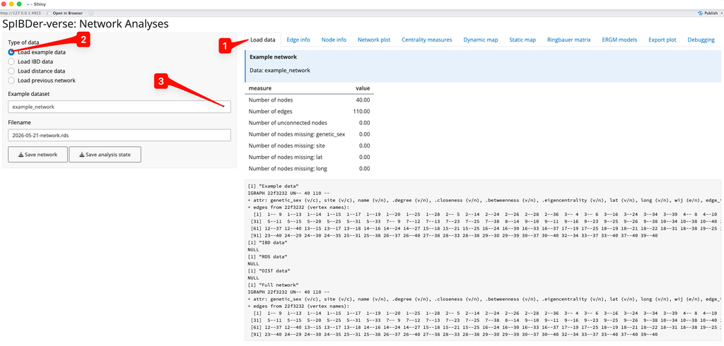

Figure 1: Load Data Tab - Load example data mode.

However, you are probably more interested in loading your own data….

## Loading your own data

We can now load in our data. For the examples here we load in the data from (Rohrlach et al. 2026), which was originally published by (Wang et al. 2025). To the IBD data we have added an edge weight, denoted $w_{ij}$, which is simply the total sum of IBD blocks ≥8cM.

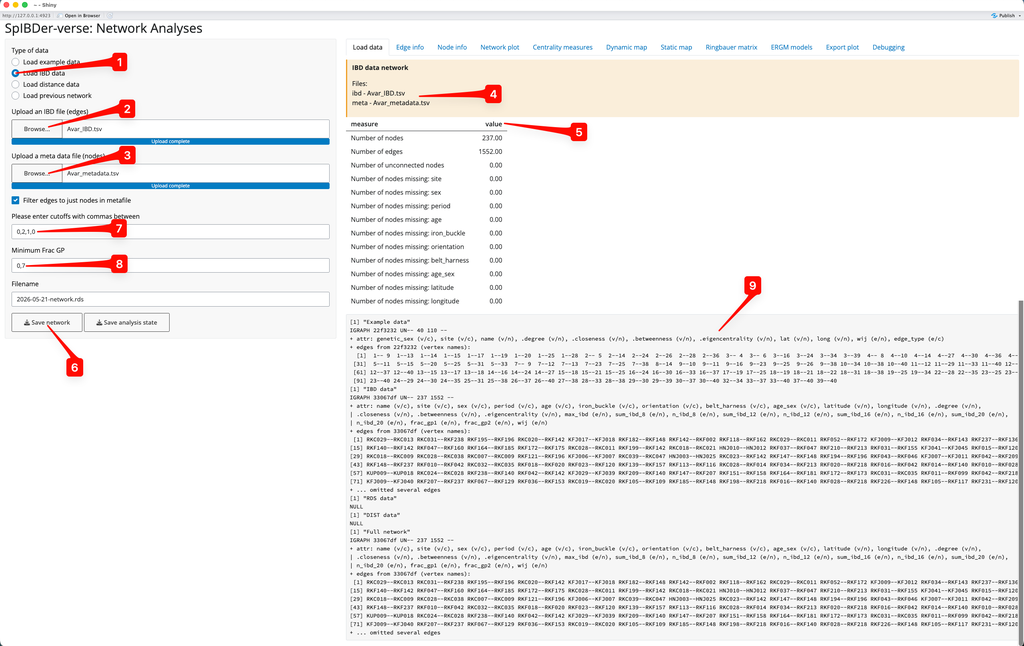

Figure 2: Load Data Tab - Load IBD data mode.

We can change to *Load IBD mode* by clicking on the correct (radio) button [1]. You will then need to upload the IBD file by clicking on the *Browse…* button for IBD files [2] (this defines the edges), and a meta data file by clicking on the *Browse…* button for meta data files [3] (this defines the nodes). Note that these files are uploaded to SpIBDer-App *on your system*, and certainly not online. Once these are files are uploaded, you can see this information in the yellow box [4].

Currently, SpIBDer-App can only accept the output from ancIBD (Ringbauer et al. 2024), and a cut off based on the number of blocks of IBD of length ≥8cM, ≥12cM, ≥16cM and ≥20cM. However, the format of the meta data table can be quite flexible: as long as the first column is made up of the names of the individuals (and matches the names in the IBD file), the remaining columns will be automatically read in. For example, SpIBDer-App has read in our meta data, and automatically realised that we have node variables called *site*, *sex*,…, *longitude* [5]. Note that information about the edges and these variables is given, counting the number edges, the number of nodes, and importantly, how many times your meta data has missing values for each node variable [5]. These variables will be made available to be used in plotting functions and in the downstream analysis tabs (introduced later in the vignette). Technically, this is also true for the IBD table, although the first two columns must now be the names of nodes (individuals), although this functionality is currently limited.

Given all of this hard work, you can save this network object at any time for later use [6], which can be loaded into SpIBDer-App to save time for continuing your analysis later (see next section).

Now we must define what we mean by an edge being “present”, and we do this by defining a string representation of the vector of IBD block length thresholds, defined $N = \left(n_{8},n_{12},n_{16},n_{20} \right)$ [7], where $n_i$ is the number of IBD blocks of length ≥$i$cM. In the ERGMs paper (Rohrlach et al. 2026) we defined two individuals as being connected/genetically related if they shared *at least* two IBD blocks of ≥12cM and one block of ≥16cM, which would be defined by the entry “0,2,1,0”. Not that we use a zero in the first entry of the string because if an individual has two IBD blocks of ≥12cM, then these two IBD blocks are also ≥8cM. Hence, “0,2,1,0” is equivalent to “2,2,1,0”. As another example, if you wished to have all edges where *any* IBD blocks (≥8cM) were detected, say for plotting the edge weights, then the string “0,0,0,0” would be sufficient.

Finally, the authors of ancIBD suggest using a quality control cut off for samples, called here the “frac_gp”, of 0.7. The frac_gp is defined as proportion of genotype posterior probabilities above the threshold of 0.99 when the sample was imputed. We make this the default, although this can be changed in the text box [8].

We have now defined our network for downstream plotting and analysis (this can be seen and ignored in the bottom right [9]). Note that you can come back to this tab to change the IBD cut off vector for relatedness, and the quality control frac_gp value at any time in the analysis.